[OHI Science](http://ohi-science.org) | [Citation policy](http://ohi-science.org/citation-policy/)

# Stressor: Direct impacts

Compiled on Mon May 7 14:12:08 2018 by frazier

From 2015 paper:

> ..we modeled direct human impact on the coast as the sum of the coastal human population, defined as the number of people within a moving circular window around each coastal cell of radius 10 km. We then cropped the data to include only cells 1km from the coast since this driver primarily affects intertidal and very nearshore ecosystems.

NOTE: 2008 paper used 25 km radius

```r
knitr::opts_chunk$set(fig.width = 6, fig.height = 4, fig.path = 'figs/',message = FALSE, warning = FALSE)

library(raster)
library(dplyr)
library(RColorBrewer)
library(sp)
library(rgdal)
library(stringr)

library(doParallel)
library(foreach)


cols <- rev(colorRampPalette(brewer.pal(9, 'Spectral'))(255))

source("https://raw.githubusercontent.com/OHI-Science/ohiprep_v2018/master/src/R/spatial_common.R")
# setwd("stressors/direct_human")

# paralell processing
cl<-makeCluster(10)
registerDoParallel(cl)
```

## Average of surrounding cells

Average of points within a 10km radius buffer around each cell. This is based on code from: https://gis.stackexchange.com/questions/151962/calculating-shannons-diversity-using-moving-window-in-r

```r
pop_files <- list.files(file.path(dir_M, "git-annex/globalprep/mar_prs_population/v2017/int"),
                        pattern = "count", full=TRUE)

for(pop_file in pop_files){ # pop_file = pop_files[1]

  rast <- raster(pop_file)
  rast_year <- str_sub(pop_file, -12, -9)

  fw <- focalWeight(rast, 10000, "circle") # creates circular filter with a radius of 10km
  #system.time({
  rast_10<-focal(rast,
                 w=fw,
                 fun=function(x,...){sum(x, na.rm=TRUE) })
    writeRaster(rast_10, file.path(dir_M, sprintf("git-annex/impact_acceleration/stressors/direct_human/int/pop_count_10km_%s.tif", rast_year)),
              overwrite=TRUE)

}
```

## Transform data

Take the ln(x+1) of the data. This helps even skew, and also assumes that impacts are non-linear.

```r
count_files <- list.files(file.path(dir_M, "git-annex/impact_acceleration/stressors/direct_human/int"),
                          pattern = "10km", full = TRUE)

for(file in count_files){ # file = count_files[1]

  yr <- as.numeric(as.character(str_sub(file, -8, -5)))

  raster(file) %>%
    calc(fun = function(x){log(x + 1)},
         filename = file.path(dir_M, sprintf("git-annex/impact_acceleration/stressors/direct_human/int/pop_count_10km_%s_log.tif", yr)),
         overwrite =TRUE)

}
```

Plot a small region of land in India to visualize what the previous code did.

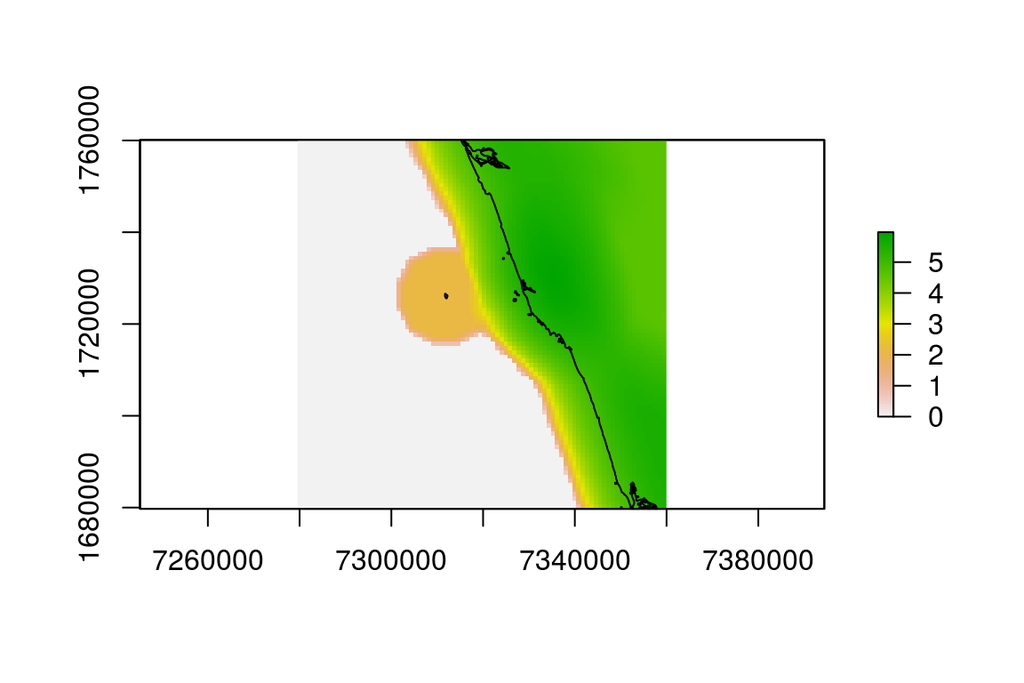

```r
land      <- regions %>%
  subset(rgn_type %in% c('land','land-disputed','land-noeez'))
land2 <- as(land, "Spatial")

tmp <- raster(file.path(dir_M, "git-annex/impact_acceleration/stressors/direct_human/int/pop_count_10km_2014_log.tif"))
tmp_extent <- c(7280000, 7360000, 1680000, 1760000)
tmp_crop <- crop(tmp, tmp_extent, col=cols)
plot(tmp_crop)
plot(land2, add=TRUE, color=NA, border="black")
```

## Mask data

Mask to 1km offshore.

```r
subs(ocean, data.frame(id=c(NA,1), v=c(1,NA)),
     filename = file.path(dir_M, "git-annex/impact_acceleration/stressors/direct_human/int/ocean_inverse.tif"),
     overwrite =TRUE)

ocean_inverse <- raster(file.path(dir_M, "git-annex/impact_acceleration/stressors/direct_human/int/ocean_inverse.tif"))

land_boundary <- boundaries(ocean_inverse, type="outer", asNA=TRUE, progress="text")
land_boundary[land_boundary == 0] <- NA

writeRaster(land_boundary, file.path(dir_M, "git-annex/impact_acceleration/stressors/direct_human/int/land_boundary.tif"),
     overwrite =TRUE)

mask_1km <- raster(file.path(dir_M, "git-annex/impact_acceleration/stressors/direct_human/int/land_boundary.tif"))
```

Make a mask that gets rid of the boundary.

```r
block <- projectRaster(ocean, crs=CRS("+init=epsg:4326"))
block[is.na(block)] <- 1
mol_solid <- projectRaster(block, ocean, over=TRUE)
boundary_mask <- boundaries(mol_solid, type="inner", asNA=TRUE, progress="text")
boundary_mask <- subs(boundary_mask, data.frame(id=c(0,1), v=c(1,NA)))
writeRaster(boundary_mask, file.path(dir_M, "git-annex/impact_acceleration/stressors/direct_human/int/boundary_mask.tif"))
boundary_mask <- raster(file.path(dir_M, "git-annex/impact_acceleration/stressors/direct_human/int/boundary_mask.tif"))
```

## Rescaling value

Determine the 99.99th quantile across all years/cells after masking to 1km offhsore.

```r
log_files <- list.files(file.path(dir_M, "git-annex/impact_acceleration/stressors/direct_human/int"),
           full=TRUE, pattern = "log.tif")
# subset to current data (not future data)
log_files <- grep(paste(2000:2016, collapse="|"), log_files, value=TRUE)

quant_data <- c()

for(file in log_files){ # file = log_files[1]

  yr <- as.numeric(as.character(str_sub(file, -12, -9)))

  tmp <- raster(file) %>%
    mask(mask_1km) %>%  # mask to get 1km offshore, unfortunately includes raster boundary
    mask(boundary_mask) # mask out raster boundary

## get values, only want values within 1 km to calcuate 99.99th quantile
  vals <- getValues(tmp)
  vals <- na.omit(vals)
  quant_data <- c(quant_data, vals)

  print(yr)
}

ref_point <- quantile(quant_data, 0.9999)
ref_point_df <- data.frame(ref_point)

write.csv(ref_point, file.path(dir_M, "git-annex/impact_acceleration/stressors/direct_human/int/ref_point.csv"))
```

## Mask ocean

Mask the ocean and replace NA values with zero.

```r
log_files <- list.files(file.path(dir_M, "git-annex/impact_acceleration/stressors/direct_human/int"),
           full=TRUE, pattern = "log.tif")

# subset to current data (not future data)
log_files <- grep(paste(2000:2016, collapse="|"), log_files, value=TRUE)

foreach(file = log_files, .packages="dplyr") %dopar%{
#for(file in log_files){ # file = log_files[1]

  yr <- as.numeric(as.character(stringr::str_sub(file, -12, -9)))

raster::raster(file) %>%
    raster::mask(mask_1km) %>%
   raster::reclassify(cbind(NA, 0), filename = file.path(dir_M, sprintf("git-annex/impact_acceleration/stressors/direct_human/int/pop_count_10km_%s_log_tmp.tif", yr)),
        overwrite =TRUE) # convert NA to zero

tmp = raster::raster(file.path(dir_M, sprintf("git-annex/impact_acceleration/stressors/direct_human/int/pop_count_10km_%s_log_tmp.tif", yr)))

  ## mask using the ocean raster
  raster::mask(tmp, ocean, filename = file.path(dir_M, sprintf("git-annex/impact_acceleration/stressors/direct_human/int/pop_count_10km_%s_log_mask.tif", yr)),
        overwrite =TRUE)
  #tmp <- raster(file.path(dir_M, sprintf("git-annex/impact_acceleration/stressors/direct_human/int/pop_count_10km_%s_log_mask.tif", yr)))

    file.remove(file.path(dir_M, sprintf("git-annex/impact_acceleration/stressors/direct_human/int/pop_count_10km_%s_log_tmp.tif", yr)))

  }
```

## Rescale data

Data are rescaled from 0-1 using the 99.99th quantile determined above.

```r
log_files <- list.files(file.path(dir_M, "git-annex/impact_acceleration/stressors/direct_human/int"),
           full=TRUE, pattern = "log_mask.tif")

# subset to current data (not future data)
log_files <- grep(paste(2000:2016, collapse="|"), log_files, value=TRUE)

# reference point
ref_point <- read.csv(file.path(dir_M, "git-annex/impact_acceleration/stressors/direct_human/int/ref_point.csv"))%>%
  select(x)
ref_point <- as.numeric(ref_point)

foreach(rast = log_files, .packages="dplyr") %dopar%{
#for(rast in log_files){ # rast = log_files[2]
  year <- as.numeric(as.character(stringr::str_sub(rast, -17, -14)))

  raster::raster(rast) %>%
    raster::calc(fun=function(x){ifelse(x<0,0,
                                ifelse(x>ref_point, 1, x/ref_point))})%>%
    raster::writeRaster(filename = file.path(dir_M,
                sprintf("git-annex/impact_acceleration/stressors/direct_human/final/direct_human_%s_rescaled_mol.tif", year)),
                overwrite=TRUE)
}
```

## Visualize data

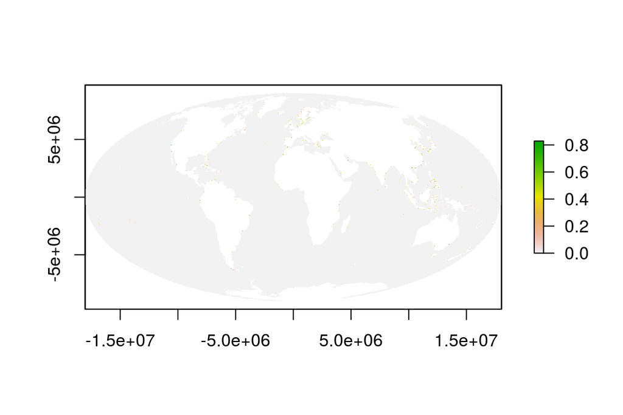

```r
tmp <- raster(file.path(dir_M, "git-annex/impact_acceleration/stressors/direct_human/final/direct_human_2001_rescaled_mol.tif"))
plot(tmp)
```